# Principles of Data Science - Course Work

Prediction cluster 0:

- In this cluster we have True Positions 3 & 4 and one value from Position 1
- PF & C positions have been joined into one as these are not only the tallest and heaviest players, but they are the most defensive type. One player is a SG in this new group

Prediction cluster 1:

- In this cluster we have True Positions 1
- All of the SGs have been clustered together except two

Prediction cluster 2:

- In this cluster its True Positions 0 and 1
- Most of this cluster are point guards and one shooting guard. This could be due to the overlapping playing styles.

Prediction cluster 3:

Prediction cluster 4:

- In this cluster True Position 2
- This cluster is the remaining of the small forwards

```python
mvp_clust['new_cluster'] = clusterLabels
```

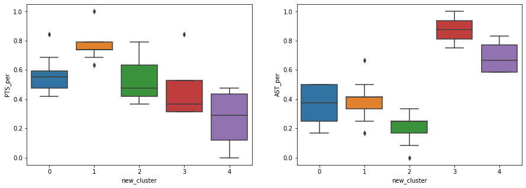

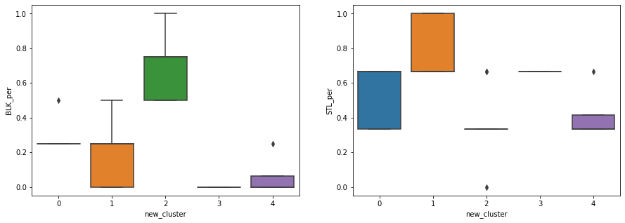

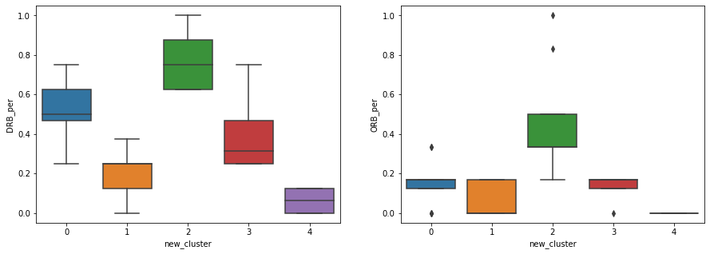

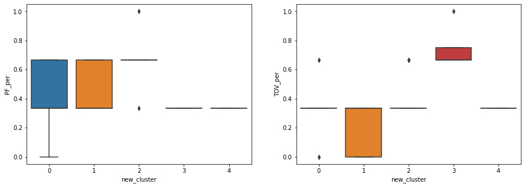

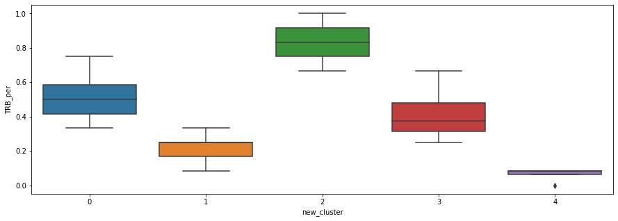

```python
# Box plot of stats for different positions

plt.figure(figsize=(15,5))
plt.subplot(1,2,1)
sns.boxplot(y='PTS_per', x ='new_cluster', data = mvp_clust)

plt.subplot(1,2,2)
sns.boxplot(y='AST_per', x ='new_cluster', data = mvp_clust)
plt.show()

plt.figure(figsize=(15,5))
plt.subplot(1,2,1)
sns.boxplot(y='BLK_per', x ='new_cluster', data = mvp_clust)

plt.subplot(1,2,2)
sns.boxplot(y='STL_per', x ='new_cluster', data = mvp_clust)
plt.show()

plt.figure(figsize=(15,5))
plt.subplot(1,2,1)
sns.boxplot(y='DRB_per', x ='new_cluster', data = mvp_clust)

plt.subplot(1,2,2)
sns.boxplot(y='ORB_per', x ='new_cluster', data = mvp_clust)
plt.show()

plt.figure(figsize=(15,5))
plt.subplot(1,2,1)
sns.boxplot(y='PF_per', x ='new_cluster', data = mvp_clust)

plt.subplot(1,2,2)
sns.boxplot(y='TOV_per', x ='new_cluster', data = mvp_clust)
plt.show()
plt.figure(figsize=(15,5))
sns.boxplot(y='TRB_per', x ='new_cluster', data = mvp_clust)
plt.show()
```

After looking at the box plots to examine the new clusters, the below are the new positions (* means new position created):

Cluster 0: CF - Center Forward*

```
- A combination of PF & C mainly.
- I can score
- We tend to steal the ball
- Good at DRB
- I can foul
- Im quite avergae across the board
- Known as 'The Big Man'
```

Cluster 1: SG - Shooting Guard

```
- The only position to stay the same
- Made up of all SGs
- King of scoring
- King of stealing
- I tend to foul
- Still known as 'The Talisman'
```

Cluster 2: PG - Power Gurad*

[output not shown]

Cluster 3: Dynamic Centre*

```
- Made of a mixture of PGs & SFs
- I can score
- Im the real assist king
- I can steal the ball alright
- Best at turning plays around
- know as "The Machine"
```

Cluster 4: AF - Assisting Forward*

```
- Made up of SF
- Im good at assisting mainly
- I can steal if I have to
- know as "The Play Maker"
```

### Outliers

MVPs outperform the rest of the population so in essence they are outliers compared to the rest. Given that MVP data is significantly disproportionate to the rest of the players I will be hesitant to remove them if they are highlighted as outliers. Let’s use Mahalanobis distance to highlight the outliers in our data.

```python
# Isolate mvp variable
outlier_mvp= df['mvp']
# Drop binary columns before running pca
outlier_data = df.drop(['mvp','final_won','final_lost','Pos','team_name','abbs','Player','college'], axis=1)

# Set PCA compnenet number
pca = PCA(n_components=2)
#fit a PCA model to the data
pca.fit(outlier_data)
pca_out = pca.transform(outlier_data)
# Create dataframe so easier to filter
pca_out = pd.DataFrame(pca_out)
# Reset index
pca_out.reset_index(drop=True, inplace=True)
outlier_mvp.reset_index(drop=True, inplace=True)
# Join dataframes
final_outlier = pd.concat([pca_out, outlier_mvp],axis=1)
# Rename columns
final_outlier.columns = ["PCA_1","PCA_2","mvp"]
final_outlier
```

|  | PCA_1 | PCA_2 | mvp |
| --- | --- | --- | --- |
| 0 | -1439.721929 | 99.042239 | 0 |
| 1 | 695.987471 | -142.420429 | 0 |
| 2 | 1360.097439 | 13.813386 | 0 |
| 3 | 943.573382 | -103.401793 | 0 |
| 4 | -1175.952405 | 65.633137 | 0 |
| ... | ... | ... | ... |
| 15920 | -1590.731272 | 144.223265 | 0 |
| 15921 | 2226.072040 | 417.622852 | 0 |
| 15922 | 1015.450585 | -428.067043 | 0 |
| 15923 | -1493.590792 | 125.143293 | 0 |
| 15924 | 415.320202 | -188.478931 | 0 |

15925 rows × 3 columns

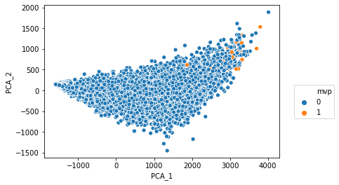

```python
# Plot scatter highlighting MVPs
out = sns.scatterplot(x="PCA_1", y="PCA_2",hue="mvp",data=final_outlier)
out.legend(loc='best', bbox_to_anchor=(1.25, 0.5), ncol=1)
plt.show()
```

```python
# Calculate Mahalanobis distance
def mahalanobis(x=None, data=None, cov=None):
    """Compute the Mahalanobis Distance between each row of x and the data
    x    : vector or matrix of data with, say, p columns.
    data : ndarray of the distribution from which Mahalanobis distance of each observation of x is to be computed.
    cov  : covariance matrix (p x p) of the distribution. If None, will be computed from data.
    """
    x_minus_mu = x - np.mean(final_outlier)
    if not cov:
        cov = np.cov(final_outlier.values.T)
    inv_covmat = np.linalg.inv(cov)
    left_term = np.dot(x_minus_mu, inv_covmat)
    mahal = np.dot(left_term, x_minus_mu.T)
    return mahal.diagonal()

df_x = final_outlier[["PCA_1","PCA_2","mvp"]]
df_x['mahala'] = mahalanobis(x=df_x, data=final_outlier[["PCA_1","PCA_2"]])
df_x.head()
```

|  | PCA_1 | PCA_2 | mvp | mahala |
| --- | --- | --- | --- | --- |
| 0 | -1439.721929 | 99.042239 | 0 | 1.561429 |
| 1 | 695.987471 | -142.420429 | 0 | 0.672750 |
| 2 | 1360.097439 | 13.813386 | 0 | 1.281448 |
| 3 | 943.573382 | -103.401793 | 0 | 0.786910 |
| 4 | -1175.952405 | 65.633137 | 0 | 1.003527 |

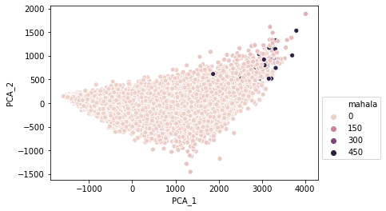

```python
# Plot Scatter using Mahalanobis distance
g = sns.scatterplot(x="PCA_1", y="PCA_2",hue="mahala",data=df_x)
g.legend(loc='best', bbox_to_anchor=(1.25, 0.5), ncol=1)
plt.show()
```

As suspected the Mahalanobis distance highlighted outliers which are identical to the MVP points. As a result, I will not be removing the outliers or else I will have no MVP data. It is one of the Logistic Regression Assumptions that no extreme outliers are present, even though visually the outliers don’t seem to be extreme in fact they are at the end of the Mahalanobis distance spectrum. This could be something for further work on how to deal with outliers in sports when analysing high preforming Athletes as they will always outperform the population.

### Correlation Analysis

One of the assumptions of Logistic Regression is no severe multicollinearity amongst the explaining variables. This why we need to check correlation in the dataset.

```python
df.info()
```

```
<class 'pandas.core.frame.DataFrame'>
Int64Index: 15925 entries, 973 to 20778
Data columns (total 61 columns):
 #   Column      Non-Null Count  Dtype
---  ------      --------------  -----
 0   Year_x      15925 non-null  float64
 1   Player      15925 non-null  object
 2   Pos         15925 non-null  object
 3   Age         15925 non-null  float64
 4   abbs        15925 non-null  object
 5   G           15925 non-null  float64
 6   GS          15925 non-null  float64
 7   MP          15925 non-null  float64
 8   PER         15925 non-null  float64
 9   TS%         15925 non-null  float64
```

[output cut: 53 more lines]

```python
# Drop selected string columns
reg=df.drop(['Year_x','Player','abbs','team_name','college','Year_y','Pos'], axis=1)
```

```python
# Display the same information numerically instead of visually
reg.corr(method='pearson')
```

|  | Age | G | GS | MP | PER | TS% | 3PAr | ORB% | DRB% | TRB% | ... | TOV_per | PF_per | PTS_per | FG_per | 3P_per | 3PA_per | 2P_per | 2PA_per | FT_per | FTA_per |
| --- | --- | --- | --- | --- | --- | --- | --- | --- | --- | --- | --- | --- | --- | --- | --- | --- | --- | --- | --- | --- | --- |
| Age | 1.000000 | 0.024315 | 0.044572 | 0.042572 | -0.004137 | 0.036168 | 0.075764 | -0.080521 | 0.023541 | -0.021029 | ... | -0.018067 | 0.032732 | 0.011358 | 0.005339 | 0.077176 | 0.064489 | -0.012360 | -0.009310 | -0.008653 | -0.028058 |
| G | 0.024315 | 1.000000 | 0.598401 | 0.844137 | 0.429465 | 0.415289 | -0.014155 | -0.060985 | 0.050558 | 0.003047 | ... | 0.484313 | 0.527862 | 0.551376 | 0.560239 | 0.232090 | 0.225785 | 0.531120 | 0.516072 | 0.451690 | 0.443735 |
| GS | 0.044572 | 0.598401 | 1.000000 | 0.848361 | 0.453688 | 0.302430 | -0.056538 | -0.041175 | 0.110065 | 0.051589 | ... | 0.640225 | 0.550508 | 0.738439 | 0.737844 | 0.276318 | 0.283043 | 0.708317 | 0.707358 | 0.625998 | 0.632241 |
| MP | 0.042572 | 0.844137 | 0.848361 | 1.000000 | 0.539331 | 0.400092 | 0.002849 | -0.098264 | 0.058447 | -0.009555 | ... | 0.711271 | 0.620262 | 0.830296 | 0.827267 | 0.352091 | 0.362052 | 0.781125 | 0.778642 | 0.703763 | 0.699469 |
| PER | -0.004137 | 0.429465 | 0.453688 | 0.539331 | 1.000000 | 0.700682 | -0.072755 | 0.161760 | 0.192993 | 0.210617 | ... | 0.471203 | 0.347876 | 0.658664 | 0.649315 | 0.206417 | 0.196769 | 0.631282 | 0.591130 | 0.614746 | 0.612015 |
| TS% | 0.036168 | 0.415289 | 0.302430 | 0.400092 | 0.700682 | 1.000000 | 0.016096 | 0.016109 | 0.106280 | 0.079311 | ... | 0.297071 | 0.330724 | 0.407994 | 0.396984 | 0.205162 | 0.166615 | 0.366042 | 0.293900 | 0.378343 | 0.365136 |
| 3PAr | 0.075764 | -0.014155 | -0.056538 | 0.002849 | -0.072755 | 0.016096 | 1.000000 | -0.489960 | -0.340532 | -0.458617 | ... | -0.073841 | -0.242875 | 0.002697 | -0.050908 | 0.685352 | 0.753782 | -0.248232 | -0.237162 | -0.114990 | -0.165716 |
| ORB% | -0.080521 | -0.060985 | -0.041175 | -0.098264 | 0.161760 | 0.016109 | -0.489960 | 1.000000 | 0.527749 | 0.838092 | ... | -0.113331 | 0.152120 | -0.116878 | -0.092519 | -0.368040 | -0.425646 | 0.011453 | -0.017779 | -0.033801 | 0.029592 |
| DRB% | 0.023541 | 0.050558 | 0.110065 | 0.058447 | 0.192993 | 0.106280 | -0.340532 | 0.527749 | 1.000000 | 0.904361 | ... | 0.015296 | 0.284300 | 0.032735 | 0.048834 | -0.214317 | -0.263050 | 0.119650 | 0.086893 | 0.081561 | 0.145203 |
| TRB% | -0.021029 | 0.003047 | 0.051589 | -0.009555 | 0.210617 | 0.079311 | -0.458617 | 0.838092 | 0.904361 | 1.000000 | ... | -0.045456 | 0.255708 | -0.035218 | -0.013144 | -0.317693 | -0.377707 | 0.083248 | 0.046931 | 0.037274 | 0.109159 |
| WS | 0.076862 | 0.625626 | 0.739858 | 0.833716 | 0.636143 | 0.444226 | -0.028543 | 0.010778 | 0.161102 | 0.114073 | ... | 0.597389 | 0.492350 | 0.803242 | 0.781459 | 0.298569 | 0.290529 | 0.746438 | 0.708021 | 0.750446 | 0.745241 |
| BPM | 0.084279 | 0.566267 | 0.514392 | 0.622852 | 0.800949 | 0.638093 | 0.045960 | 0.033933 | 0.127812 | 0.102206 | ... | 0.454876 | 0.471326 | 0.587965 | 0.578879 | 0.279412 | 0.273485 | 0.537445 | 0.494716 | 0.514842 | 0.512413 |
| VORP | 0.053078 | 0.421391 | 0.651118 | 0.683695 | 0.564611 | 0.341680 | 0.019467 | 0.022756 | 0.161562 | 0.120441 | ... | 0.548663 | 0.394627 | 0.704459 | 0.678080 | 0.302395 | 0.308827 | 0.635106 | 0.599506 | 0.657722 | 0.661480 |
| FG | 0.000719 | 0.711014 | 0.791939 | 0.921029 | 0.605759 | 0.376057 | -0.056368 | -0.078714 | 0.050086 | -0.004862 | ... | 0.742677 | 0.558857 | 0.935718 | 0.939621 | 0.307253 | 0.321538 | 0.910697 | 0.905438 | 0.798229 | 0.793253 |
| FGA | 0.002916 | 0.719439 | 0.788966 | 0.927025 | 0.582248 | 0.343495 | 0.004179 | -0.126583 | 0.007642 | -0.056340 | ... | 0.746593 | 0.540664 | 0.933056 | 0.930148 | 0.373568 | 0.397950 | 0.882219 | 0.893058 | 0.789706 | 0.776909 |
| FG% | -0.002937 | 0.369774 | 0.275196 | 0.334022 | 0.627560 | 0.867257 | -0.305829 | 0.204586 | 0.241247 | 0.257862 | ... | 0.250695 | 0.372670 | 0.320624 | 0.351334 | -0.069855 | -0.122167 | 0.395092 | 0.311085 | 0.270818 | 0.297607 |
| 3P | 0.061617 | 0.360030 | 0.367325 | 0.472552 | 0.242109 | 0.220038 | 0.638102 | -0.370652 | -0.221522 | -0.323234 | ... | 0.283139 | 0.081027 | 0.450142 | 0.387865 | 0.908570 | 0.929189 | 0.161491 | 0.179911 | 0.279936 | 0.225710 |
| 3PA | 0.052840 | 0.377926 | 0.381811 | 0.493827 | 0.247465 | 0.205691 | 0.641819 | -0.382448 | -0.230118 | -0.334842 | ... | 0.312866 | 0.090903 | 0.470172 | 0.407942 | 0.899462 | 0.939252 | 0.185023 | 0.206235 | 0.302855 | 0.249132 |
| 2P | -0.013717 | 0.679735 | 0.765021 | 0.879059 | 0.594308 | 0.352549 | -0.210659 | 0.002539 | 0.105941 | 0.070785 | ... | 0.731858 | 0.581765 | 0.900121 | 0.918962 | 0.116661 | 0.127170 | 0.941101 | 0.931116 | 0.792334 | 0.799737 |
| 2PA | -0.013287 | 0.690497 | 0.767460 | 0.887584 | 0.577132 | 0.321761 | -0.196512 | -0.022439 | 0.080736 | 0.041621 | ... | 0.741428 | 0.579455 | 0.901782 | 0.918021 | 0.138078 | 0.153020 | 0.934012 | 0.939550 | 0.793045 | 0.795497 |
| FT | -0.009403 | 0.607300 | 0.708274 | 0.822392 | 0.597704 | 0.369768 | -0.103980 | -0.034936 | 0.079822 | 0.036230 | ... | 0.734833 | 0.518608 | 0.890743 | 0.847616 | 0.232653 | 0.250397 | 0.833592 | 0.832155 | 0.927747 | 0.916781 |
| FTA | -0.025529 | 0.621521 | 0.716593 | 0.828606 | 0.600123 | 0.369550 | -0.143092 | 0.014052 | 0.130361 | 0.092581 | ... | 0.739552 | 0.552550 | 0.880965 | 0.845014 | 0.190165 | 0.204249 | 0.843319 | 0.836381 | 0.914584 | 0.928195 |
| FT% | 0.077552 | 0.385261 | 0.233730 | 0.355403 | 0.366122 | 0.437027 | 0.167803 | -0.264716 | -0.149767 | -0.227684 | ... | 0.294019 | 0.201186 | 0.374523 | 0.347689 | 0.266697 | 0.287352 | 0.292755 | 0.304428 | 0.358973 | 0.278567 |
| ORB | -0.025631 | 0.596243 | 0.592725 | 0.666353 | 0.437508 | 0.306201 | -0.357832 | 0.406967 | 0.471037 | 0.501885 | ... | 0.453864 | 0.637158 | 0.524844 | 0.551520 | -0.130820 | -0.159393 | 0.625362 | 0.593111 | 0.503514 | 0.564252 |
| DRB | 0.044778 | 0.671690 | 0.725794 | 0.808230 | 0.508604 | 0.353210 | -0.169637 | 0.190215 | 0.483412 | 0.406717 | ... | 0.570874 | 0.642570 | 0.670323 | 0.678953 | 0.111594 | 0.096305 | 0.693524 | 0.668471 | 0.606211 | 0.645544 |
| TRB | 0.023068 | 0.667229 | 0.704091 | 0.786128 | 0.500651 | 0.348462 | -0.236388 | 0.266939 | 0.493932 | 0.450147 | ... | 0.549761 | 0.660169 | 0.642884 | 0.657684 | 0.035563 | 0.015462 | 0.692107 | 0.663941 | 0.590851 | 0.638380 |
| AST | 0.040614 | 0.547815 | 0.617735 | 0.717676 | 0.427895 | 0.238700 | 0.094256 | -0.296711 | -0.218317 | -0.284566 | ... | 0.682999 | 0.313544 | 0.629814 | 0.612276 | 0.338486 | 0.380342 | 0.552394 | 0.567166 | 0.544095 | 0.512016 |
| STL | -0.004958 | 0.684827 | 0.697027 | 0.831685 | 0.485595 | 0.298500 | 0.041970 | -0.172850 | -0.090836 | -0.143026 | ... | 0.664948 | 0.481996 | 0.703404 | 0.695783 | 0.315907 | 0.351652 | 0.648578 | 0.654978 | 0.596387 | 0.584699 |
| BLK | -0.006300 | 0.431316 | 0.464301 | 0.488822 | 0.347736 | 0.233647 | -0.264046 | 0.269364 | 0.433272 | 0.413361 | ... | 0.327471 | 0.523014 | 0.379833 | 0.400033 | -0.097537 | -0.127405 | 0.455974 | 0.423629 | 0.365931 | 0.425059 |
| TOV | -0.023704 | 0.719903 | 0.765791 | 0.895444 | 0.538840 | 0.343226 | -0.078376 | -0.093271 | 0.032456 | -0.023549 | ... | 0.858348 | 0.593242 | 0.839019 | 0.828843 | 0.252505 | 0.275097 | 0.808756 | 0.812329 | 0.770519 | 0.771434 |
| PF | 0.005428 | 0.844266 | 0.700739 | 0.857961 | 0.438885 | 0.384526 | -0.176936 | 0.089000 | 0.216858 | 0.183131 | ... | 0.597006 | 0.810933 | 0.634616 | 0.647971 | 0.116689 | 0.102211 | 0.657818 | 0.642506 | 0.559088 | 0.578948 |
| PTS | 0.003518 | 0.704527 | 0.789117 | 0.921197 | 0.613012 | 0.386037 | -0.013319 | -0.098066 | 0.037570 | -0.022234 | ... | 0.750896 | 0.546370 | 0.945878 | 0.933945 | 0.360006 | 0.376519 | 0.890184 | 0.887407 | 0.836180 | 0.825457 |
| mvp | 0.015310 | 0.045183 | 0.078973 | 0.086874 | 0.122829 | 0.045890 | -0.005907 | 0.001289 | 0.038548 | 0.028035 | ... | 0.097924 | 0.024552 | 0.145806 | 0.138328 | 0.042488 | 0.041598 | 0.134082 | 0.123386 | 0.153364 | 0.146718 |
| final_won | 0.061408 | 0.037127 | 0.012612 | 0.019839 | 0.029959 | 0.036305 | 0.009312 | 0.009085 | 0.005339 | 0.012554 | ... | -0.003912 | -0.013694 | 0.012312 | 0.016216 | 0.004493 | 0.000633 | 0.014106 | 0.001892 | -0.000495 | 0.000664 |
| final_lost | 0.047476 | 0.027543 | 0.018272 | 0.023419 | 0.036404 | 0.036149 | 0.006168 | 0.012616 | 0.002065 | 0.012597 | ... | 0.010558 | -0.005188 | 0.020678 | 0.019175 | 0.006457 | 0.002085 | 0.017301 | 0.008473 | 0.023071 | 0.020856 |
| height | 0.002674 | -0.016330 | 0.023958 | -0.040041 | 0.012375 | 0.044294 | -0.349529 | 0.487690 | 0.582462 | 0.614923 | ... | -0.118620 | 0.209106 | -0.048680 | -0.028246 | -0.243437 | -0.299829 | 0.046318 | 0.015101 | -0.001521 | 0.050218 |
| weight_y | -0.034164 | -0.039631 | 0.015346 | -0.056915 | 0.025084 | 0.040111 | -0.317157 | 0.478206 | 0.584883 | 0.611740 | ... | -0.113968 | 0.180515 | -0.055244 | -0.040219 | -0.209153 | -0.263729 | 0.023767 | -0.006575 | -0.006640 | 0.048302 |
| experience | 0.725313 | 0.057048 | 0.097432 | 0.102372 | 0.053835 | 0.064275 | 0.102268 | -0.103090 | 0.032087 | -0.027478 | ... | 0.037522 | 0.050166 | 0.098591 | 0.090623 | 0.129058 | 0.126497 | 0.063271 | 0.065649 | 0.062792 | 0.048751 |
| ORB_per | -0.029885 | 0.380216 | 0.474091 | 0.488460 | 0.409588 | 0.256086 | -0.434023 | 0.553358 | 0.535968 | 0.614757 | ... | 0.394573 | 0.612059 | 0.450962 | 0.478212 | -0.186908 | -0.222629 | 0.564644 | 0.538581 | 0.454400 | 0.523449 |
| DRB_per | 0.067422 | 0.479162 | 0.639882 | 0.667566 | 0.501561 | 0.329141 | -0.200306 | 0.240854 | 0.606953 | 0.510431 | ... | 0.559806 | 0.651541 | 0.644154 | 0.652375 | 0.080992 | 0.064610 | 0.675181 | 0.654763 | 0.594425 | 0.645912 |
| TRB_per | 0.040935 | 0.471238 | 0.618081 | 0.643166 | 0.498492 | 0.323346 | -0.287696 | 0.363252 | 0.620100 | 0.577916 | ... | 0.533695 | 0.676710 | 0.613669 | 0.628810 | -0.008551 | -0.031603 | 0.675773 | 0.651028 | 0.579031 | 0.640281 |
| AST_per | 0.058016 | 0.403146 | 0.539701 | 0.606594 | 0.410847 | 0.205028 | 0.133900 | -0.354359 | -0.267829 | -0.345345 | ... | 0.696068 | 0.281221 | 0.606910 | 0.586338 | 0.344373 | 0.398911 | 0.522357 | 0.545094 | 0.526699 | 0.493736 |
| STL_per | 0.018555 | 0.467161 | 0.563436 | 0.654468 | 0.434012 | 0.238944 | 0.078239 | -0.201448 | -0.110871 | -0.170994 | ... | 0.612382 | 0.433102 | 0.629778 | 0.619477 | 0.306491 | 0.347683 | 0.570105 | 0.586877 | 0.532647 | 0.524563 |
| BLK_per | -0.007068 | 0.244818 | 0.343151 | 0.321875 | 0.296803 | 0.178917 | -0.289412 | 0.298849 | 0.452611 | 0.439522 | ... | 0.254287 | 0.459914 | 0.289662 | 0.311323 | -0.149360 | -0.181174 | 0.376305 | 0.346829 | 0.290714 | 0.353575 |
| TOV_per | -0.018067 | 0.484313 | 0.640225 | 0.711271 | 0.471203 | 0.297071 | -0.073841 | -0.113331 | 0.015296 | -0.045456 | ... | 1.000000 | 0.563990 | 0.795172 | 0.781783 | 0.234407 | 0.266186 | 0.764010 | 0.777859 | 0.744906 | 0.749321 |
| PF_per | 0.032732 | 0.527862 | 0.550508 | 0.620262 | 0.347876 | 0.330724 | -0.242875 | 0.152120 | 0.284300 | 0.255708 | ... | 0.563990 | 1.000000 | 0.554091 | 0.567824 | 0.044147 | 0.026047 | 0.595135 | 0.586818 | 0.506727 | 0.542923 |
| PTS_per | 0.011358 | 0.551376 | 0.738439 | 0.830296 | 0.658664 | 0.407994 | 0.002697 | -0.116878 | 0.032735 | -0.035218 | ... | 0.795172 | 0.554091 | 1.000000 | 0.981250 | 0.389939 | 0.413690 | 0.932293 | 0.936523 | 0.889837 | 0.881015 |
| FG_per | 0.005339 | 0.560239 | 0.737844 | 0.827267 | 0.649315 | 0.396984 | -0.050908 | -0.092519 | 0.048834 | -0.013144 | ... | 0.781783 | 0.567824 | 0.981250 | 1.000000 | 0.326586 | 0.347138 | 0.960686 | 0.953519 | 0.836581 | 0.835313 |
| 3P_per | 0.077176 | 0.232090 | 0.276318 | 0.352091 | 0.206417 | 0.205162 | 0.685352 | -0.368040 | -0.214317 | -0.317693 | ... | 0.234407 | 0.044147 | 0.389939 | 0.326586 | 1.000000 | 0.923598 | 0.099180 | 0.118939 | 0.226448 | 0.174342 |
| 3PA_per | 0.064489 | 0.225785 | 0.283043 | 0.362052 | 0.196769 | 0.166615 | 0.753782 | -0.425646 | -0.263050 | -0.377707 | ... | 0.266186 | 0.026047 | 0.413690 | 0.347138 | 0.923598 | 1.000000 | 0.113895 | 0.139787 | 0.247536 | 0.192096 |
| 2P_per | -0.012360 | 0.531120 | 0.708317 | 0.781125 | 0.631282 | 0.366042 | -0.248232 | 0.011453 | 0.119650 | 0.083248 | ... | 0.764010 | 0.595135 | 0.932293 | 0.960686 | 0.099180 | 0.113895 | 1.000000 | 0.977319 | 0.824201 | 0.837758 |
| 2PA_per | -0.009310 | 0.516072 | 0.707358 | 0.778642 | 0.591130 | 0.293900 | -0.237162 | -0.017779 | 0.086893 | 0.046931 | ... | 0.777859 | 0.586818 | 0.936523 | 0.953519 | 0.118939 | 0.139787 | 0.977319 | 1.000000 | 0.831276 | 0.838755 |
| FT_per | -0.008653 | 0.451690 | 0.625998 | 0.703763 | 0.614746 | 0.378343 | -0.114990 | -0.033801 | 0.081561 | 0.037274 | ... | 0.744906 | 0.506727 | 0.889837 | 0.836581 | 0.226448 | 0.247536 | 0.824201 | 0.831276 | 1.000000 | 0.950832 |
| FTA_per | -0.028058 | 0.443735 | 0.632241 | 0.699469 | 0.612015 | 0.365136 | -0.165716 | 0.029592 | 0.145203 | 0.109159 | ... | 0.749321 | 0.542923 | 0.881015 | 0.835313 | 0.174342 | 0.192096 | 0.837758 | 0.838755 | 0.950832 | 1.000000 |

54 rows × 54 columns

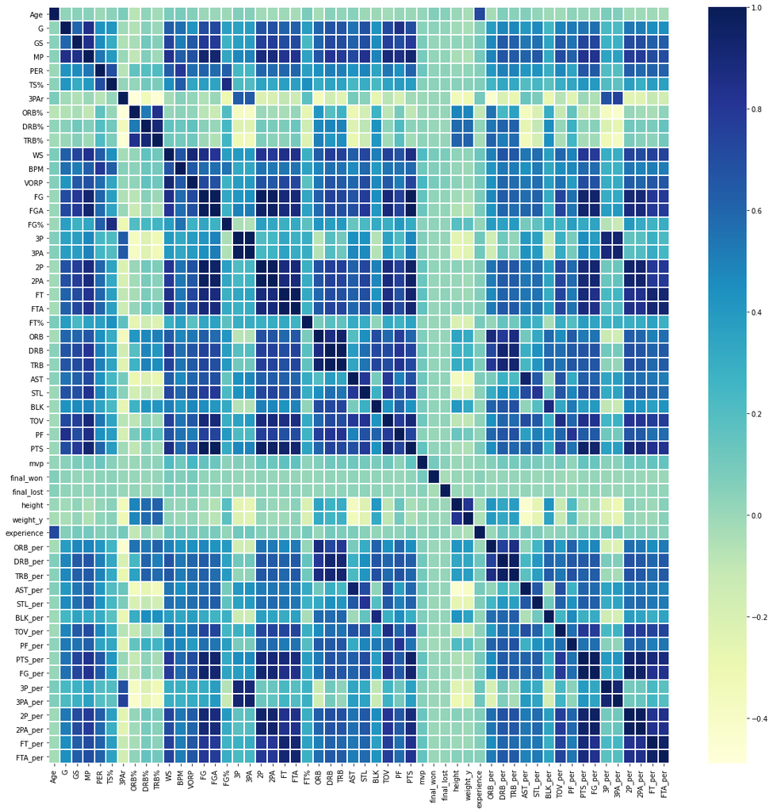

```python
# Ensure the plot displays in a large enough
plt.figure(figsize=(20,20))
# Create heatmap of the correlations
sns.heatmap(reg.corr(method='pearson'),cmap='YlGnBu',linewidth=1,linecolor='white')
plt.show()
```

One of the Logistic Regression assumptions is Observation independent, meaning each the observations are independent from each other or related to each other in any way. This means we cannot use any advance statistics in the model as they are all calculated from the basic statistics, hence why we have some highly correlated variables in the correlation matrix above. So, we will go ahead and only select the basic stats.

```python
# Create smaller dataframe of basic stats
feats = df[['Age','G','GS','MP','experience','ORB_per','DRB_per','AST_per','STL_per','BLK_per',
            'TOV_per','PF_per','PTS_per','FG_per','3P_per','3PA_per','2P_per','2PA_per','FT_per','FTA_per',
            'final_won','final_lost','mvp']]
```

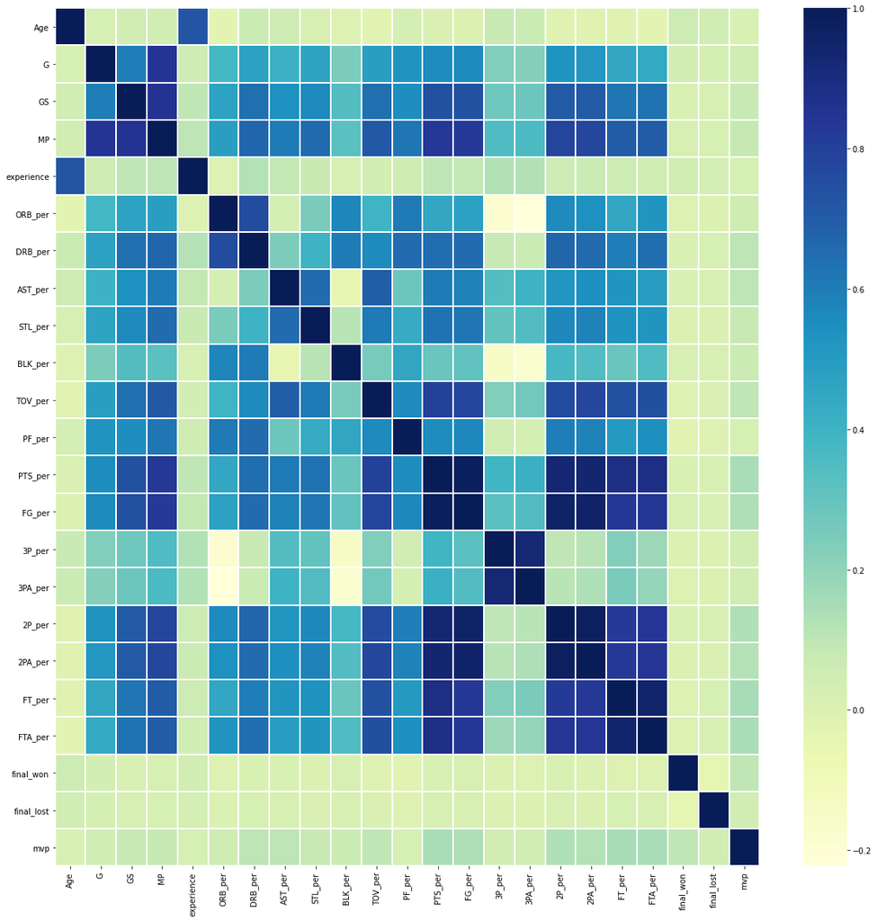

```python
# Ensure the plot displays in a large enough
plt.figure(figsize=(20,20))
# Create heatmap of the correlations
sns.heatmap(feats.corr(method='pearson'),cmap='YlGnBu',linewidth=1,linecolor='white')
plt.show()
```

As we know, another Logistic regression assumption is no multicollinearity amongst explanatory variables. As a result, we will drop some columns to remove any high correlation.

```python
# Drop Highly correlated columns
feats.drop(['experience','MP','GS','3PA_per','2P_per','2PA_per','FTA_per','FG_per','FT_per','ORB_per'],axis=1,inplace=True)
```

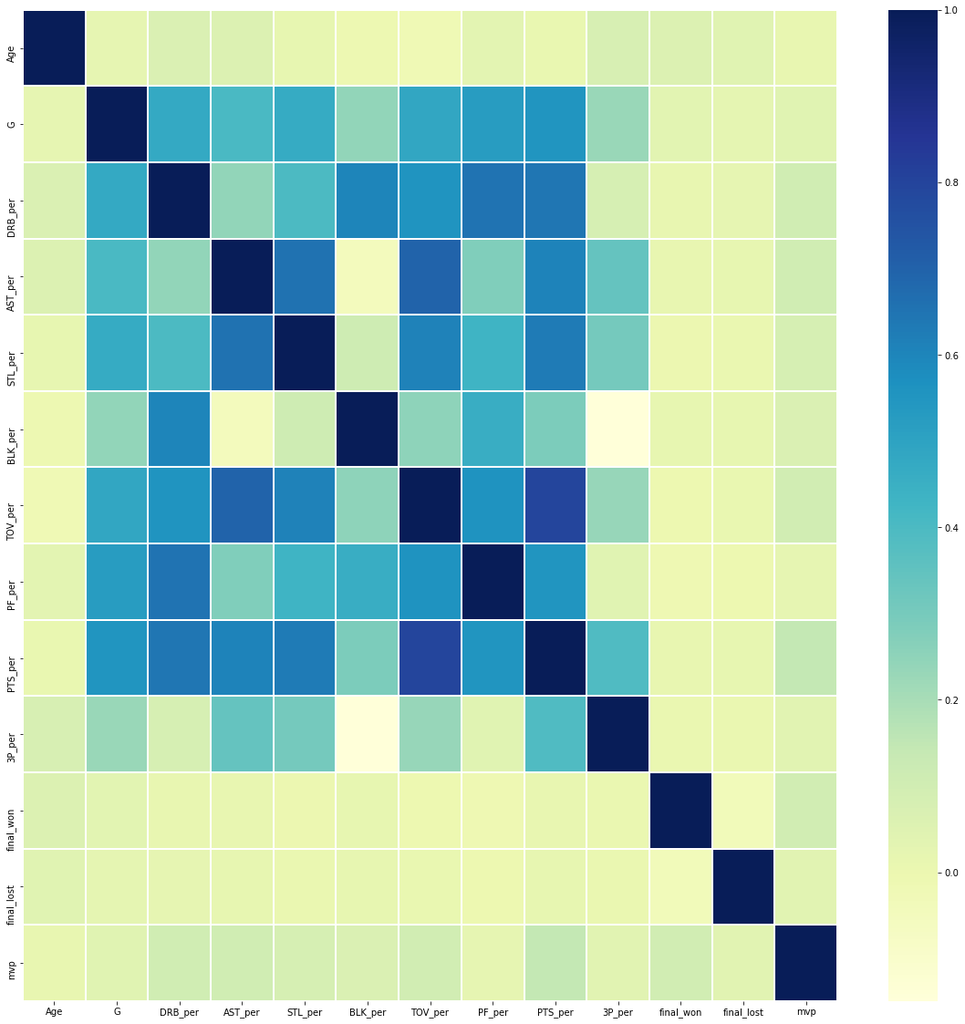

```python
# Ensure the plot displays in a large enough
plt.figure(figsize=(20,20))
# Create heatmap of the correlations
sns.heatmap(feats.corr(method='pearson'),cmap='YlGnBu',linewidth=1,linecolor='white')
plt.show()
```

```python
# Select columns that are no binary to scale
cols_norm = ['Age','G','DRB_per','AST_per','STL_per','BLK_per','TOV_per','PF_per','PTS_per','3P_per']

# Scale the metrics as they are quite varied
scaler = preprocessing.MinMaxScaler()
feats[cols_norm]= scaler.fit_transform(feats[cols_norm])
```

```python
# Lets take a look at the table
feats.head()
```

|  | Age | G | DRB_per | AST_per | STL_per | BLK_per | TOV_per | PF_per | PTS_per | 3P_per | final_won | final_lost | mvp |
| --- | --- | --- | --- | --- | --- | --- | --- | --- | --- | --- | --- | --- | --- |
| 973 | 0.384615 | 0.130952 | 0.166667 | 0.066667 | 0.25 | 0.000000 | 0.166667 | 0.333333 | 0.081081 | 0.0 | 0.0 | 0.0 | 0 |
| 974 | 0.269231 | 0.857143 | 0.333333 | 0.133333 | 0.25 | 0.166667 | 0.333333 | 0.500000 | 0.270270 | 0.0 | 0.0 | 0.0 | 0 |
| 975 | 0.576923 | 0.952381 | 0.166667 | 0.266667 | 0.25 | 0.000000 | 0.333333 | 0.500000 | 0.324324 | 0.0 | 0.0 | 0.0 | 0 |
| 976 | 0.307692 | 0.928571 | 0.333333 | 0.133333 | 0.00 | 0.000000 | 0.333333 | 0.500000 | 0.297297 | 0.0 | 0.0 | 0.0 | 0 |
| 977 | 0.384615 | 0.369048 | 0.083333 | 0.066667 | 0.00 | 0.000000 | 0.166667 | 0.333333 | 0.108108 | 0.0 | 0.0 | 0.0 | 0 |

# Predicting MVP

For this section we will use Logistic Regression to predict an MVP player based on independent and non-correlated basic performance statistics.

Model: Logistic Regression

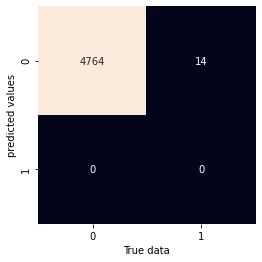

```
              precision    recall  f1-score   support

           0       1.00      1.00      1.00      4764
           1       0.00      0.00      0.00        14

    accuracy                           1.00      4778
   macro avg       0.50      0.50      0.50      4778
weighted avg       0.99      1.00      1.00      4778
```

```python
# Import Packages
from sklearn.model_selection import train_test_split
from sklearn.linear_model import LogisticRegression
from sklearn.metrics import classification_report
# Define X values for the model
X = feats[['Age','G','DRB_per','AST_per','STL_per','BLK_per','TOV_per','PF_per','PTS_per','3P_per',
           'final_won','final_lost']]
# Define Y value
y = feats['mvp']
# Set groups and split
X_train, X_test, y_train, y_test = train_test_split(X, y, test_size = .3, random_state=25)
# Create model
LogReg = LogisticRegression()
LogReg.fit(X_train, y_train)
# Predict on unseen data
y_pred = LogReg.predict(X_test)

# Import package
from sklearn.metrics import confusion_matrix
# Create Confusion Matrix to analyse model
mat = confusion_matrix(y_test,y_pred)
sns.heatmap(mat.T, square =True, annot = True, fmt = 'd', cbar= False)
plt.xlabel('True data')
plt.ylabel('predicted values')
plt.show()
# Print performance metrics
print(classification_report(y_test, y_pred))
```

```python
# Lets look at each coefficient to understand its role
coefficients = np.column_stack((np.asarray(feats[['Age','G','DRB_per','AST_per','STL_per','BLK_per','TOV_per','PF_per','PTS_per','3P_per',
           'final_won','final_lost']].columns), LogReg.coef_.flatten()))
print(coefficients)
```

```
[['Age' 0.6097750595953161]
 ['G' 1.2938051269381152]
 ['DRB_per' 2.538036531907583]
 ['AST_per' 1.9202729785196726]
 ['STL_per' 1.6008412950826176]
 ['BLK_per' 0.8175942244752704]
 ['TOV_per' 1.0323742068917956]
 ['PF_per' -0.4583788382481145]
 ['PTS_per' 4.074273139732507]
 ['3P_per' 1.3244116334062837]
 ['final_won' 2.1104411560222234]
 ['final_lost' 1.37473609083568]]
```

As we can see from our results that the model was very accurate in predicting normal players with no inaccuracies. Where the model failed was in its Recall metric for value equals “1”, which is predicting MVP players. Out of the 14 MVPs in the test data the model wasn’t able to predict one MVP correctly.

From the predictors that had the strongest influence were ‘PTS_per & ‘DRB_per’

The next steps will be to validate the results using K-fold and to further try to improve the model despite already normalising predictors, ensuring predictors were independent and removing highly correlated predictors.

# K-Fold Validation:

```
Run:  0
15925 13270 2655
```

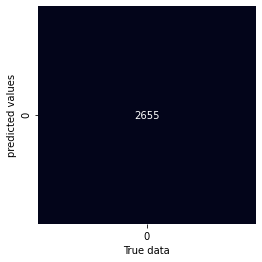

```
              precision    recall  f1-score   support

           0       1.00      1.00      1.00      2655

    accuracy                           1.00      2655
   macro avg       1.00      1.00      1.00      2655
weighted avg       1.00      1.00      1.00      2655

Run:  1
15925 13271 2654
```

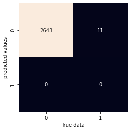

```
              precision    recall  f1-score   support

           0       1.00      1.00      1.00      2643
           1       0.00      0.00      0.00        11

    accuracy                           1.00      2654
   macro avg       0.50      0.50      0.50      2654
weighted avg       0.99      1.00      0.99      2654

Run:  2
15925 13271 2654
```

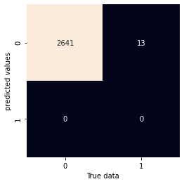

```
              precision    recall  f1-score   support

           0       1.00      1.00      1.00      2641
           1       0.00      0.00      0.00        13

    accuracy                           1.00      2654
   macro avg       0.50      0.50      0.50      2654
weighted avg       0.99      1.00      0.99      2654

Run:  3
15925 13271 2654
```

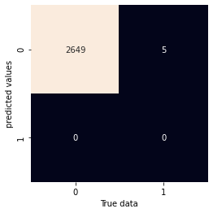

```
              precision    recall  f1-score   support

           0       1.00      1.00      1.00      2649
           1       0.00      0.00      0.00         5

    accuracy                           1.00      2654
   macro avg       0.50      0.50      0.50      2654
weighted avg       1.00      1.00      1.00      2654

Run:  4
15925 13271 2654
```

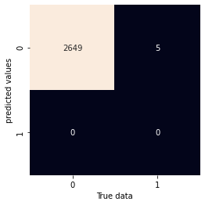

```
              precision    recall  f1-score   support

           0       1.00      1.00      1.00      2649
           1       0.00      0.00      0.00         5

    accuracy                           1.00      2654
   macro avg       0.50      0.50      0.50      2654
weighted avg       1.00      1.00      1.00      2654

Run:  5
15925 13271 2654
```

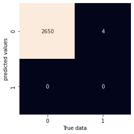

```
              precision    recall  f1-score   support

           0       1.00      1.00      1.00      2650
           1       0.00      0.00      0.00         4

    accuracy                           1.00      2654
   macro avg       0.50      0.50      0.50      2654
weighted avg       1.00      1.00      1.00      2654
```

```python
# Import packages
from sklearn.model_selection import KFold
import scipy.stats as stats
import numpy as np

kf = KFold(n_splits=6)
foldCount = 0
for train_idxs, test_idxs in kf.split(feats):
    print("Run: ", foldCount)
    print(len(feats),len(train_idxs),len(test_idxs))
    ytrain = y.iloc[train_idxs]
    Xtrain = X.iloc[train_idxs]
    ytest = y.iloc[test_idxs]
    Xtest = X.iloc[test_idxs]
    # Create the model
    LogReg = LogisticRegression()
    LogReg.fit(Xtrain, ytrain)
    # Predict on unseen data
    y_pred = LogReg.predict(Xtest)

    # Confusion matrix
    mat = confusion_matrix(ytest,y_pred)
    sns.heatmap(mat.T, square =True, annot = True, fmt = 'd', cbar= False)
    plt.xlabel('True data')
    plt.ylabel('predicted values')
    plt.show()
    # Print performance metrics
    print(classification_report(ytest, y_pred))
    foldCount += 1
```

After validating the model, we can see that the model was unable to predict any MVPs at all.

# Improve the Model:

Influential predictors:

We will first rerun the model using only the predictors that had strongest influence and see how this changes the outcome

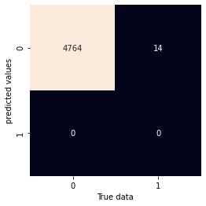

```
              precision    recall  f1-score   support

           0       1.00      1.00      1.00      4764
           1       0.00      0.00      0.00        14

    accuracy                           1.00      4778
   macro avg       0.50      0.50      0.50      4778
weighted avg       0.99      1.00      1.00      4778
```

```python
# Set X values
X2 = feats[['PTS_per','DRB_per','AST_per','final_won']]
# Set Y value
y2 =feats['mvp']
X2_train, X2_test, y2_train, y2_test = train_test_split(X2, y2, test_size = .3, random_state=25)

#Build model
LogReg = LogisticRegression()
LogReg.fit(X2_train, y2_train)
# Predict on unseen data
y2_pred = LogReg.predict(X2_test)

# Confusion matrix
mat = confusion_matrix(y2_test,y2_pred)
sns.heatmap(mat.T, square =True, annot = True, fmt = 'd', cbar= False)
plt.xlabel('True data')
plt.ylabel('predicted values')
plt.show()
# Print performance metrics
print(classification_report(y2_test, y2_pred))
```

As we can see the model accuracy is the same, with still no MVP predicted correctly at all.

To evaluate it seems more difficult to predict the MVP by their basic performance statistics despite feature engineering, normalising, ensuring independence within predictors and removing correlated predictors. But looking at our data we can see it suffered from class imbalance which can make it hard for the model to classify when there is only a small number of MVP rows to learn from. For future reference we could try different classification techniques such as decision trees to see if we can improve upon this technique or we could manipulate the data to have a more balanced spread of either class to improve the models or use an algorism that is better equipped for this kind of dataset like anomaly detection. We should also remember we were unable to remove outliers which could of effected the model potentially or the fact the points in the data that were most important to us are considered outliers.